# Homework 1

*Ginevra Carbone*

## DAAG

### Exercise 4

For the data frame ais (DAAG package) (a) Use the function str() to get information on each of the columns. Determine whether any of the columns hold missing values.

```r
library(DAAG)
str(ais)
```

```
## 'data.frame':    202 obs. of  13 variables:
##  $ rcc   : num  3.96 4.41 4.14 4.11 4.45 4.1 4.31 4.42 4.3 4.51 ...
##  $ wcc   : num  7.5 8.3 5 5.3 6.8 4.4 5.3 5.7 8.9 4.4 ...
##  $ hc    : num  37.5 38.2 36.4 37.3 41.5 37.4 39.6 39.9 41.1 41.6 ...
##  $ hg    : num  12.3 12.7 11.6 12.6 14 12.5 12.8 13.2 13.5 12.7 ...
##  $ ferr  : num  60 68 21 69 29 42 73 44 41 44 ...
##  $ bmi   : num  20.6 20.7 21.9 21.9 19 ...
##  $ ssf   : num  109.1 102.8 104.6 126.4 80.3 ...
##  $ pcBfat: num  19.8 21.3 19.9 23.7 17.6 ...
##  $ lbm   : num  63.3 58.5 55.4 57.2 53.2 ...
##  $ ht    : num  196 190 178 185 185 ...
##  $ wt    : num  78.9 74.4 69.1 74.9 64.6 63.7 75.2 62.3 66.5 62.9 ...
##  $ sex   : Factor w/ 2 levels "f","m": 1 1 1 1 1 1 1 1 1 1 ...
##  $ sport : Factor w/ 10 levels "B_Ball","Field",..: 1 1 1 1 1 1 1 1 1 1 ...
```

```r
which(is.na(ais))
```

```
## integer(0)
```

2. Make a table that shows the numbers of males and females for each different sport. In which sports is there a large imbalance (e.g., by a factor of more than 2:1) in the numbers of the two sexes?

```r
library(tidyr)
library(dplyr)
df <- as.data.frame.matrix(t(table(ais$sex, ais$sport)))
df
```

```
##          f  m
## B_Ball  13 12
## Field    7 12
## Gym      4  0
## Netball 23  0
## Row     22 15
## Swim     9 13
## T_400m  11 18
## T_Sprnt  4 11
## Tennis   7  4
## W_Polo   0 17
```

```r
df[which(df$f > 2*df$m | df$f*2 < df$m),]
```

```
##          f  m
## Gym      4  0
## Netball 23  0
## T_Sprnt  4 11
## W_Polo   0 17
```

### Exercise 6

Create a data frame called `Manitoba.lakes` that contains the lake’s elevation (in meters above sea level) and area (in square kilometers) as listed below. Assign the names of the lakes using the `row.names()` function.

```r
elevation <- c(217,254,248,254,253,227,178,207,217)
area <- c(24387,5374,4624,2247,1353,1223,1151,755,657)
names <- c("Winnipeg", "Winnipegosis", "Manitoba", "SouthernIndian", "Cedar", "Island", "Gods", "Cross", "Playgreen")
Manitoba.lakes <- data.frame(elevation, area, row.names = names)
Manitoba.lakes
```

```
##                elevation  area
## Winnipeg             217 24387
## Winnipegosis         254  5374
## Manitoba             248  4624
## SouthernIndian       254  2247
## Cedar                253  1353
## Island               227  1223
## Gods                 178  1151
## Cross                207   755
## Playgreen            217   657
```

1. Use the following code to plot `log2(area)` versus `elevation`, adding labeling information (there is an extreme value of area that makes a logarithmic scale pretty much essential):

```r
attach(Manitoba.lakes)
```

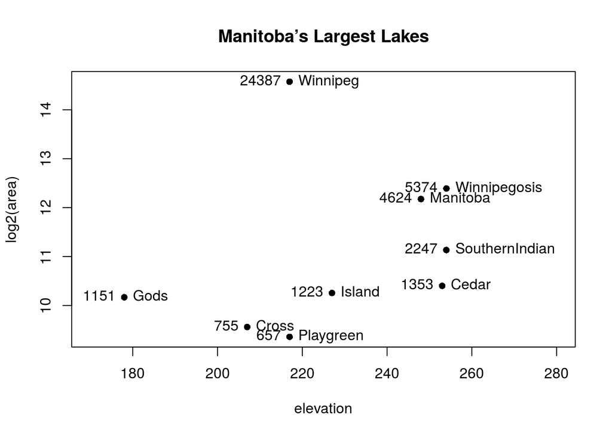

```r
plot(log2(area) ~ elevation, pch=16, xlim=c(170,280))
# NB: Doubling the area increases log2(area) by 1.0
text(log2(area) ~ elevation, labels=row.names(Manitoba.lakes), pos=4)
text(log2(area) ~ elevation, labels=area, pos=2)
title("Manitoba’s Largest Lakes")
```

```r
detach(Manitoba.lakes)
```

Devise captions that explain the labeling on the points and on the y-axis. It will be necessary to explain how distances on the scale relate to changes in area.

2. Repeat the plot and associated labeling, now plotting area versus elevation, but specifying log=“y” in order to obtain a logarithmic y-scale. [Note: The log=“y” setting carries across to the subsequent text() commands. See Subsection 2.1.5 for an example.]

```r
attach(Manitoba.lakes)
```

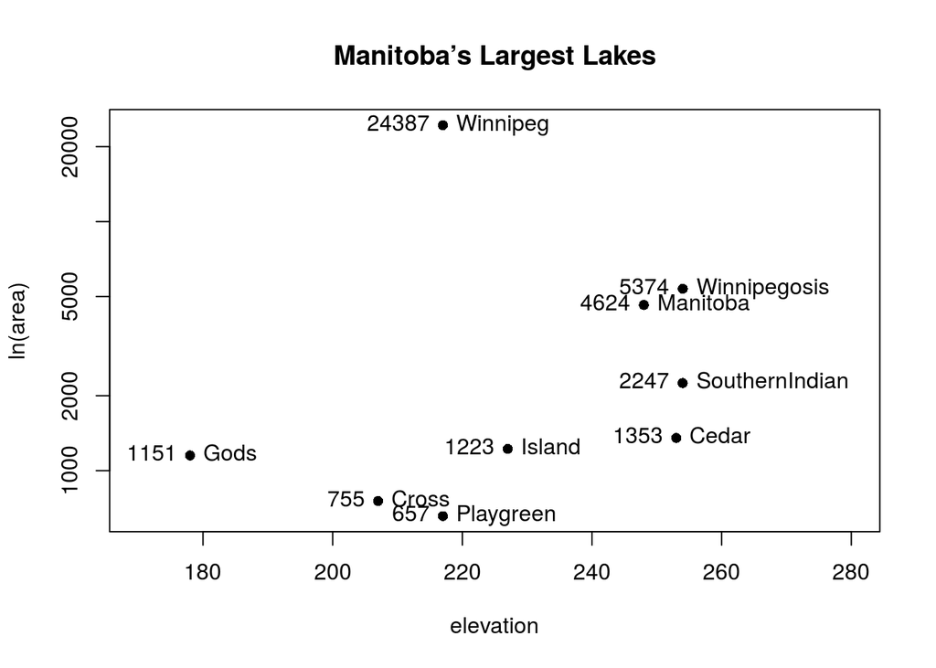

```r
plot(area ~ elevation, log="y", pch=16, xlim=c(170,280), ylab="ln(area)")
text(area ~ elevation, labels=row.names(Manitoba.lakes), pos=4)
text(area ~ elevation, labels=area, pos=2)
title("Manitoba’s Largest Lakes")
```

```r
detach(Manitoba.lakes)
```

### Exercise 11

Run the following code and explain the output from the successive uses of table().

```r
gender <- factor(c(rep("female", 91), rep("male", 92)))

table(gender)
```

```
## gender
## female   male
##     91     92
```

*gender is a vector with two levels: “female”, repeated 91 times, and “male”, repeated 92 times.*

```r
gender <- factor(gender, levels=c("male", "female"))

table(gender)
```

```
## gender
##   male female
##     92     91
```

*This commands creates a new vector from `gender` by selecting the levels in reverse order.*

```r
gender <- factor(gender, levels=c("Male", "female"))
# Note the mistake: "Male" should be "male"
table(gender)
```

```
## gender
##   Male female
##      0     91
```

```r
table(gender, exclude=NULL)
```

```
## gender
##   Male female   <NA>
##      0     91     92
```

```r
rm(gender)
# Remove gender
```

*This last table includes a new column for NA values.*

### Exercise 12

Write a function that calculates the proportion of values in a vector `x` that exceed some value `cutoff`. (a) Use the sequence of numbers 1, 2, . . . , 100 to check that this function gives the result that is expected. (b) Obtain the vector `ex01.36` from the `Devore6` (or `Devore7`) package. These data give the times required for individuals to escape from an oil platform during a drill. Use `dotplot()` to show the distribution of times. Calculate the proportion of escape times that exceed 7 minutes.

```r
prop <- function(x, cutoff){
  y <- x[x > cutoff]
  return(length(y)/length(x))
}

x <- c(1:100)
prop(x, 60)
```

```
## [1] 0.4
```

```r
library(Devore7)
```

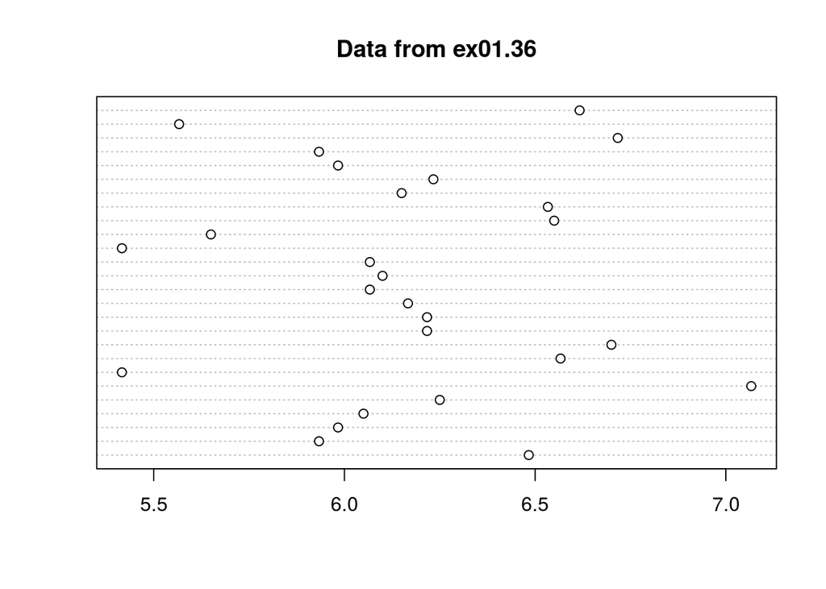

```r
library(ggplot2)
vec <- unlist(ex01.36/60, use.names=FALSE)

# dotplot has now become dotchart
dotchart(vec, main="Data from ex01.36")
```

```r
prop(vec, 7)
```

```
## [1] 0.03846154
```

### Exercise 13

The following plots four different transformations of the Animals data from the MASS package. What different aspects of the data do these different graphs emphasize? Consider the effect on low values of the variables, as contrasted with the effect on high values.

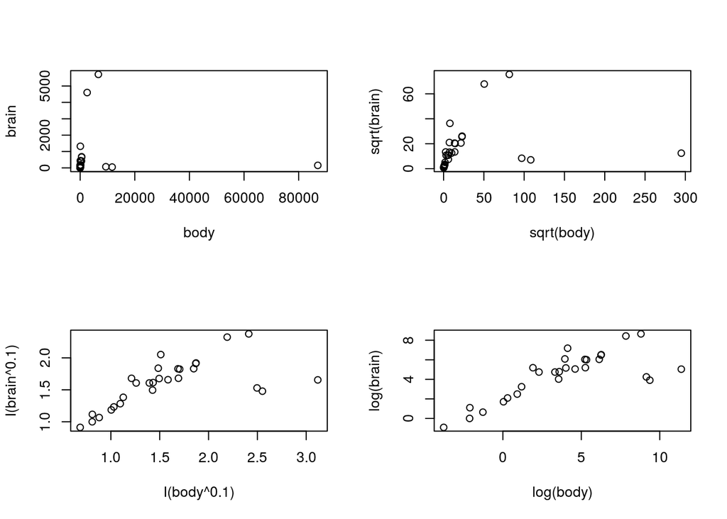

```r
par(mfrow=c(2,2))
# 2 by 2 layout on the page
library(MASS)
# Animals is in the MASS package
plot(brain ~ body, data=Animals)
plot(sqrt(brain) ~ sqrt(body), data=Animals)
plot(I(brain^0.1) ~ I(body^0.1), data=Animals)
# I() forces its argument to be treated "as is"
plot(log(brain) ~ log(body), data=Animals)
```

```r
par(mfrow=c(1,1))
# Restore to 1 figure per page
```

*These graphs show how to obtain a better visualization of data, through the composition with different functions: we can notice that in all cases low values are expanded, while high values are shrinked.*

### Exercise 15

The data frame socsupport (DAAG) has data from a survey on social and other kinds of support, for a group of university students. It includes Beck Depression Inventory (BDI) scores. The following are two alternative plots of BDI against age:

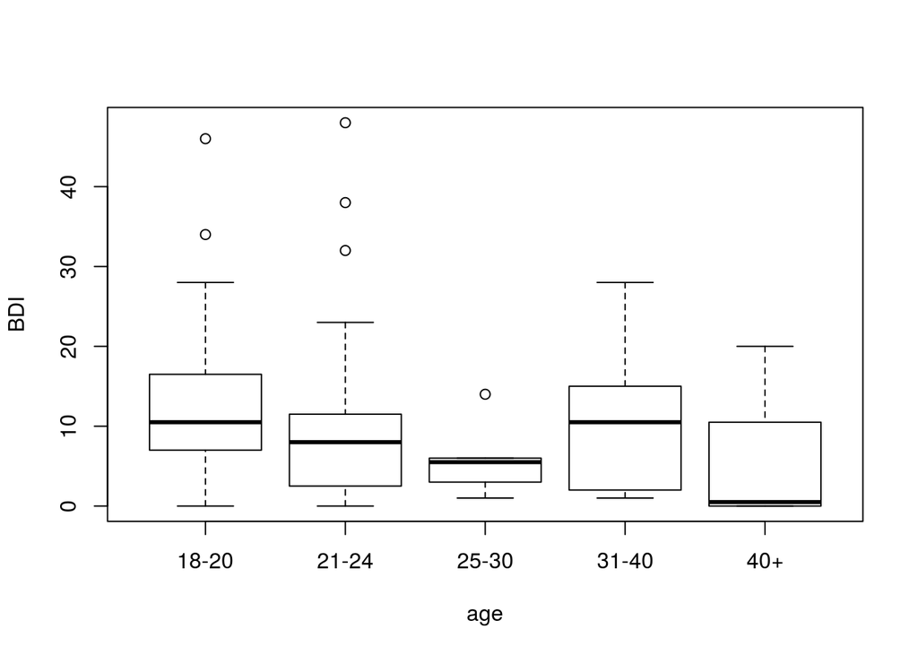

```r
plot(BDI ~ age, data=socsupport)
```

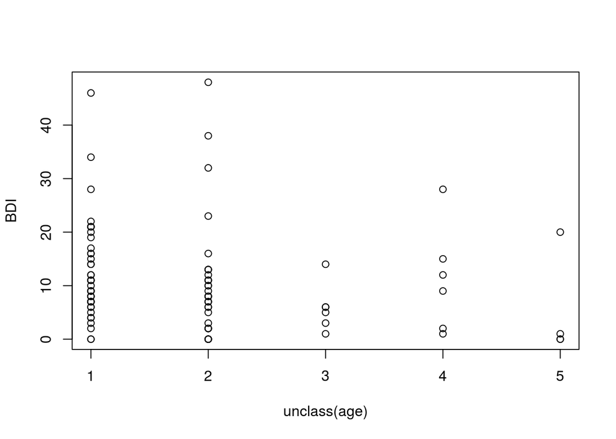

```r
plot(BDI ~ unclass(age), data=socsupport)
```

For examination of cases where the score seems very high, which plot is more useful? Explain.

*18-20 and 31-40 categories are the ones having higher median. The first boxplot is more useful, since it has a higher number of observations.*

Why is it necessary to be cautious in making anything of the plots for students in the three oldest age categories (25-30, 31-40, 40+)?

*Because of the low number of observations available.*